# Homework 3 - Covid cases over time

Pau Blasco Roca. NIU: 1600959

15/5/2022

## Covid cases evolution analysis

The number of registered cases of COVID-19 in Catalonia, day by day, from 27/02/2020 to 31/03/2020:

*y = c(2, 3, 5, 6, 15, 15, 15, 24, 24, 24, 49, 75, 124, 156, 260, 316, 509, 715, 903, 1394, 1866, 2702, 3270, 4203, 4704, 5925, 7864, 9937, 11592, 12940, 1423, 15026, 16157, 18773)*

We want to analyze the evolution of the number of affected individuals as a function of time A(t).

### Exercise 1: Exponential fit

We will fit the data using these two exponential functions.

$A_1(t)=\exp(\beta_0+\beta_1t),\quad A_2(t)=\exp(\beta_0+\beta_1t+\beta_2t^2)$

We are going to assume our data is Poisson distributed. Let’s first store our data in a dataset.

```r
cases = c(2, 3, 5, 6, 15, 15, 15, 24, 24, 24, 49, 75, 124, 156, 260, 316, 509, 715, 903, 1394, 1866, 2702, 3270, 4203, 4704, 5925, 7864, 9937, 11592, 12940, 1423, 15026, 16157, 18773)
days = seq(1,length(cases),1)
myData <- data.frame("cases" = cases, "days" = days)
```

We will fit the model with both functions and compare their results. We will start using the **glm** method.

```r
t <- seq(1, length(myData$days), 1)
t2 <- t*t
f2 <- glm(cases ~ t, family="poisson", data=myData)
summary(f2)$aic
```

```
## [1] 24278.81
```

```r
f4 <- glm(cases ~ t + t2, family="poisson",data=myData)
summary(f4)$aic
```

```
## [1] 17978.65
```

Our results are AIC=24278.81 for the first function and AIC=17978.65 for the second function. We see that, as the second one has a lower value, is the best option for us. Let’s plot both functions and study how well they adjust to the data.

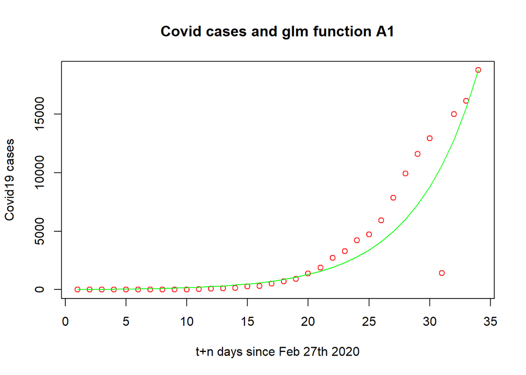

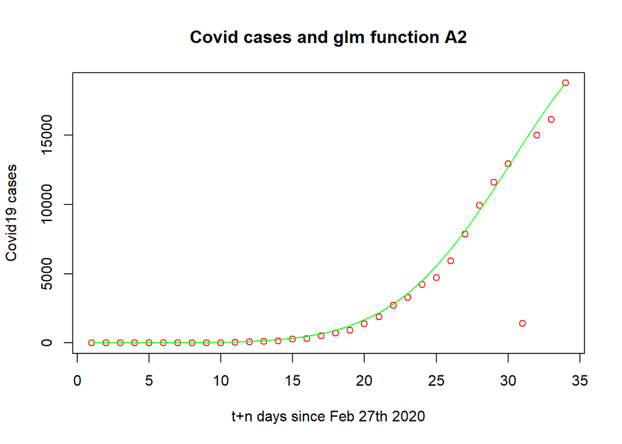

After plotting both options, we can see how the second one adjusts slightly better to our data.

We will now study the model using the **nlm** method. For that, we will first need to compute the maximum likelihood estimator for each function. Luckily, R makes that process really simple.

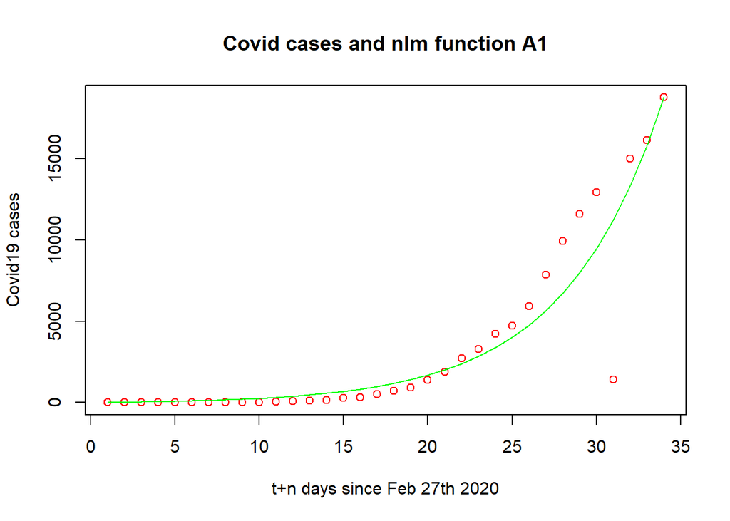

```r
loglik=function(par){
  f = (exp(b0 + b1*t))
  return(-sum(myData$cases*log(f)-f))
}
#These initial parameters seem to give the best results
param=nlm(loglik, p=c(1,0.17),hessian = TRUE)
b0 = param$estimate[1]
b1 = param$estimate[2]
f2c <- function(t) { return (exp(b0 + b1*t)) }
plot(myData$days,  myData$cases, type="p", col="red", ylab="Covid19 cases", xlab="t+n days since Feb 27th 2020" )
par(new=TRUE)
plot(myData$days, f2c(myData$days), type="l", col="green", axes=FALSE, main="Covid cases and nlm function A1",xlab="", ylab="" )
```

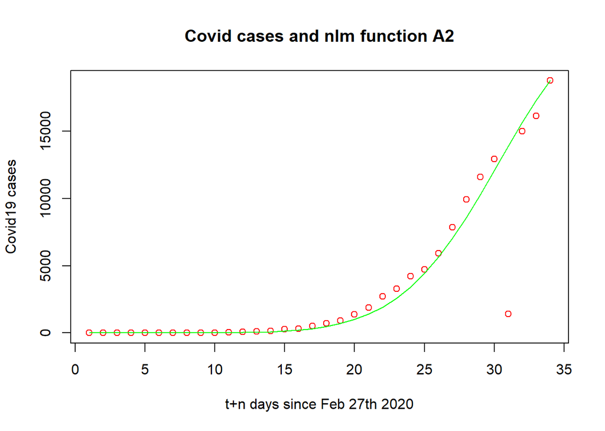

```r
loglik=function(par){
  f = (exp(b0 + b1*t + b2*t**2))
  return(-sum(myData$cases*log(f)-f))
}
#These initial parameters seem to give the best results
param=nlm(loglik, p=c(2,0.75,-0.01),hessian = TRUE)
b0 = param$estimate[1]
b1 = param$estimate[2]
b2 = param$estimate[3]
f4c <- function(t) { return (exp(b0 + b1*t + b2*t**2)) }
plot(myData$days,  myData$cases, type="p", col="red", ylab="Covid19 cases", xlab="t+n days since Feb 27th 2020" )
par(new=TRUE)
plot(myData$days, f4c(myData$days), type="l", col="green", axes=FALSE, main="Covid cases and nlm function A2",xlab="", ylab="" )
```

Now we must find the expected time at where the cases will stop growing. For that, we will just optimize $A_2$.

```r
f4 <- glm(cases ~ t + t2, family="poisson",data=myData)
b0 <- summary(f4)$coefficients[1]
b1 <- summary(f4)$coefficients[2]
b2 <- summary(f4)$coefficients[3]
f4c <- function(t) { return (exp(b0 + b1*t + b2*t**2)) }
optimize(f4c, c(1, length(cases)+10), maximum=TRUE)
```

```
## $maximum
## [1] 38.35119
##
## $objective
## [1] 18801.67
```

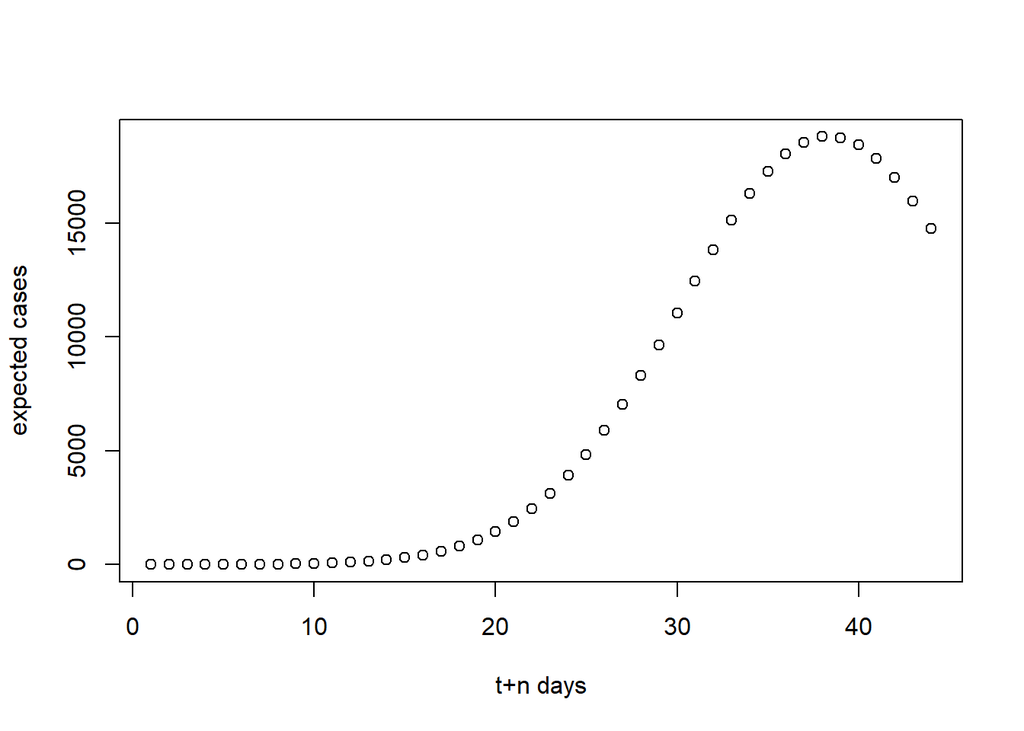

```r
plot(seq(1,length(cases)+10,1), f4c(seq(1,length(cases)+10,1)), xlab="t+n days", ylab="expected cases")
```

As we can clearly see, the maximum takes place in day 38.35 (between days 38 and 39). I have plotted the function for 10 more days to make it clear that the maximum takes place in that day.

### Exercise 2: Two-parameters Sigmoid fit

We will fit the data using this sigmoid-like function.

$A(t)=\frac{A_0C}{A_0+(C-A_0)\exp(-\beta t)},\quad\textrm{where }A(0)=A_0\textrm{ and }\beta>0.$

This model is not a **glm** model, as the function is not linear and therefore, glm won’t be able to handle it. For this, we need to use **nlm**.

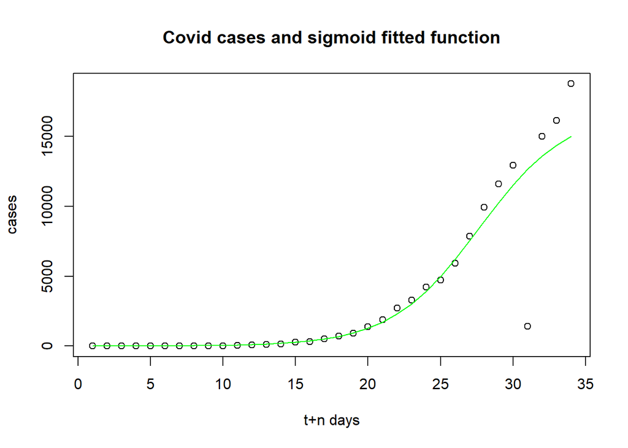

```r
A0 = myData$cases[1]
loglik=function(par){
  f = ((A0*par[1])/(A0+(par[1]-A0)*exp(-par[2]*myData$days)))
  return(-sum(myData$cases*log(f)-f))
}
#We use the initial parameters as the first value of the sample.
param=nlm(loglik, p=c(2,1),hessian = TRUE)
C = param$estimate[1]
b1 = param$estimate[2]
f6 <- function(a0,x){ return((a0*C)/(a0+(C-a0)*exp(-b1*x)))}

plot(myData$days, myData$cases, pch=1, xlab="t+n days", ylab="cases", main="Covid cases and sigmoid fitted function")
lines(myData$days, f6(A0,myData$days), col="green")
```

We can easily compute the limit of this function by studying it mathematically. Our function, fitted to our data, is the following:
$$A(t)=\frac{2·16888}{2+16888\exp(-0.32698
t)},\quad\textrm{where }A(0)=A_0\textrm{ and }\beta>0.$$
Which clearly tends to $C$, in our case $16888$, as time tends to infinity.

To estimate C with a 95% confidence interval, we need to use the following formula:
$$C=\hat{C}\pm1.96\frac{1}{\sqrt{J(\hat{C})}}$$
Where $J(\hat{C})=-l''(\hat{C}))$. Differentiating two times the log-likelihood, we get the hessian matrix:

```r
fi= param$hessian
sol <- solve(fi)
sigm <- sol[1,1]
sqrt(sigm)
```

```
## [1] 101.9012
```

Then, we get a window of $\pm1.96·101.9$ which gives us the following CI: $(16688.276,17087.724)$.